# Statistical Inference Part 1 - Course Project

Clay Burns

June 18, 2015

## Purpose

This report will explore the exponential distribution in R and compare it with the Cnetral Limit Theorem. This distribution can be simulated in R with rexp(n, lambda) where lambda is the rate paratmeter. The mean of the distrubtion is 1/lamdba and the stand deviation is also 1/lambda. The set lambda = .2 for all of the simulations. The exploration will cover a distribution of 40 exponentials and have a thousand simlultions.

## Simulations

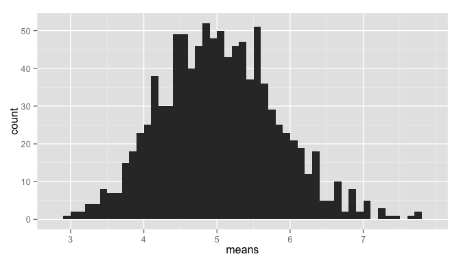

```r
# load neccesary libraries
library(ggplot2)

# set constants n(40) = exponetial, lambda(.2) for rexp, number of tests = 1000
lambda <- 0.2
n <- 40
numberOfSimulations <- 1000

# set the seed to create reproducability
set.seed(22678979)

# run the test resulting in n(40) x numberOfSimulations(1000) matrix
exponentialDistributions <- matrix(data=rexp(n * numberOfSimulations, lambda), nrow=numberOfSimulations)
exponentialDistributionMeans <- data.frame(means=apply(exponentialDistributions, 1, mean))
```

## Sample Mean versus Theoretical Mean

The expected mean $\mu$ of a exponential distribution of rate $\lambda$ is

$\mu= \frac{1}{\lambda}$

```r
mu <- 1/lambda
mu
```

```
## [1] 5
```

Let $\bar X$ be the average sample mean of 1000 simulations of 40 randomly sampled exponential distributions.

```r
meanOfMeans <- mean(exponentialDistributionMeans$means)
meanOfMeans
```

```
## [1] 5.035169
```

The two figures are very close.

## Sample Variance versus Theoretical Variance

The expected standard deviation $\sigma$ of a exponential distribution of rate $\lambda$ is

$\sigma = \frac{1/\lambda}{\sqrt{n}}$

```r
sd <- 1/lambda/sqrt(n)
sd
```

```
## [1] 0.7905694
```

The variance $Var$ of standard deviation $\sigma$ is

$Var = \sigma^2$

```r
Var <- sd^2
Var
```

```
## [1] 0.625
```

Let $Var_x$ be the variance of the average sample mean of 1000 simulations of 40 randomly sampled exponential distribution, and $\sigma_x$ the corresponding standard deviation.

```r
sd_x <- sd(exponentialDistributionMeans$means)
sd_x
```

```
## [1] 0.7983913
```

```r
Var_x <- var(exponentialDistributionMeans$means)
Var_x
```

```
## [1] 0.6374287
```

Both figures are quite close but since variance is squared minor difference will likelyy be enhanced more.

## Distribution

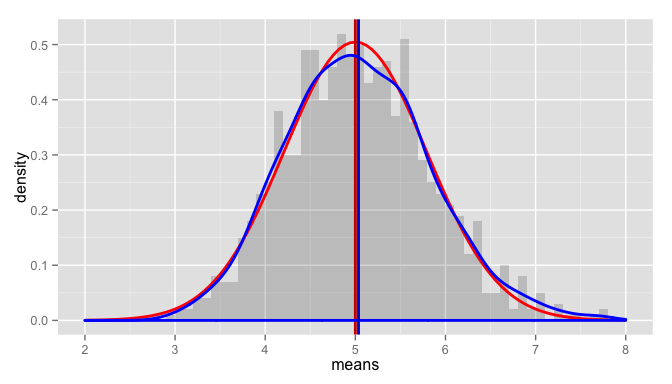

The graph show just how true the central limit theorm is by how nicely the mean lines line up.